# Abstract

This project investigates whether historical price and volume data can be used to predict the daily directional movement of NVIDIA Corporation (NVDA) stock over a decade-long period from January 2016 to December 2025. As one of the most closely watched equities in the market, NVIDIA presents a particularly compelling case study for testing the limits of quantitative forecasting. The analysis is grounded in two competing theoretical frameworks: the Efficient Market Hypothesis (EMH), which holds that all publicly available information is already priced in, and the Adaptive Markets Hypothesis (AMH), which allows for temporary inefficiencies in highly volatile assets. Understanding which framework better describes NVIDIA’s behavior has practical implications for retail investors, quantitative analysts, and anyone evaluating the feasibility of algorithmic trading strategies on high-profile large-cap equities.

# Introduction

The academic foundation of stock forecasting begins with the Efficient Market Hypothesis (EMH), famously championed by Eugene Fama in the 1960s. The EMH states stock prices follow a “random walk,” meaning all known information is already “priced in,” and future movements are impossible to predict consistently. Under this framework, any attempt to forecast NVIDIA’s daily direction would be no more effective than a coin flip. However, as the field of behavioral finance emerged, researchers began to identify “market anomalies”, persistent patterns driven by human psychology, such as overreaction to news or herding behavior. This led to the Adaptive Markets Hypothesis (AMH), which suggests that while markets are generally efficient, they undergo periods of temporary inefficiency. For a high-volatility stock like NVDA, these periods of inefficiency offer a window for quantitative models to capture “alpha” by identifying recurring structural patterns in historical data.

# Literature Review

In statistical finance, the primary challenge for modeling stock price movements is that financial time series are rarely stationary, meaning they are not independent and identically distributed (i.i.d.). As noted by Cont (2001), financial returns exhibit characteristic “stylized facts”: fat tails, volatility clustering, and little to no autocorrelation in returns. These properties motivate the need for stationarity testing, typically using the Augmented Dickey-Fuller (ADF) test (Dickey & Fuller, 1979), before applying any time-series model.

For univariate time-series forecasting, the Autoregressive Integrated Moving Average (ARIMA) model (Box & Jenkins, 1970) is a standard starting point. ARIMA uses past values and past forecast errors to predict future values, and handles non-stationary series through differencing. In practice, `auto.arima` (Hyndman & Khandakar, 2008) automates the model selection process by searching over candidate AR and MA orders using information criteria such as AIC.

Beyond pure time-series models, framing next-day price direction as a binary classification problem (will the stock close higher or lower?) allows us to apply standard supervised learning methods. Logistic regression provides an interpretable linear baseline, while ensemble methods like Random Forest (Breiman, 2001) capture non-linear relationships between engineered features such as RSI, MACD, and rolling volatility. Fischer & Krauss (2018) demonstrate that these feature-rich approaches can extract meaningful signal from technical indicators in financial classification tasks, though performance tends to hover close to the random-walk baseline for large-cap equities, a result broadly consistent with the Efficient Market Hypothesis.

# Data Introduction

This project utilizes a historical dataset of NVIDIA Corporation (NVDA) stock, covering the decade-long period from January 2016 to December 2025. The dataset was sourced from Kaggle and consists of 2,514 daily trading observations (stocks only trade on business days). Given the objective of constructing a predictive framework for directional movement, the data is structured as a multivariate time-series containing the following variables:

- **Date**: The trading date, serving as the temporal index for the series.
- **Open / High / Low / Close**: Daily price metrics in USD, representing the opening, peak, trough, and final settlement prices, respectively.
- **Volume**: The total number of shares traded during the session, which serves as a proxy for market liquidity and institutional interest.

# EDA

## Feature Engineering

Before exploring the data visually, we first construct a set of derived features that will be used throughout the remainder of this analysis and in subsequent modeling. Raw OHLCV data alone is insufficient for capturing the kinds of signals relevant to stock forecasting. Price levels are non-stationary, volume varies across market regimes, and intraday structure (such as where the close lands relative to the day’s range) is lost when only looking at individual columns in isolation. Feature engineering transforms these raw inputs into a richer representation that makes latent market dynamics more accessible to both visualization and modeling.

The features are organized into four groups: price-derived measures, rolling and lagged return features, standard technical indicators from the quantitative finance literature, and volume-normalized features. Together, they form the full feature set `df_model` used for all downstream analysis.

```
## Rows after feature engineering: 2480
```

```
## Features available:
```

```
##  [1] "Date"           "Close"          "High"           "Low"
##  [5] "Open"           "Volume"         "Volume_M"       "daily_range"
##  [9] "overnight_gap"  "close_position" "log_return"     "lag1"
## [13] "lag2"           "lag3"           "lag4"           "lag5"
## [17] "vol_5d"         "vol_20d"        "ma_5d"          "ma_20d"
## [21] "sma_20"         "price_vs_sma20" "rsi_14"         "macd"
## [25] "macd_signal"    "macd_hist"      "bb_pct_b"       "bb_width"
## [29] "vol_ma20"       "rel_volume"     "log_volume"     "target"
```

The engineered feature set reflects four distinct perspectives on market behavior. The first group captures price structure: intraday range, overnight gap, and close position describe the geometry of how wide the day’s move was, whether the stock opened with a gap relative to the prior close, and where within the day’s range the price ultimately settled. The second group consists of return-based features: the contemporaneous log return alongside five lagged versions, plus 5- and 20-day rolling means and standard deviations of those returns, which together encode short-term momentum, mean-reversion tendencies, and the recent volatility regime. The third group covers standard technical indicators drawn from the quantitative finance literature, which are RSI, MACD histogram, and Bollinger Band metrics. Each of them distills a different aspect of trend strength, momentum crossovers, and price position relative to a volatility-adjusted envelope. Finally, the fourth group addresses volume dynamics through relative volume (today’s volume normalized against its 20-day average) and log-transformed raw volume, which distinguish between structurally high-volume periods and days of unusual institutional activity. Taken together, these 20 features represent a broad sweep of the information available in daily OHLCV data, deliberately designed so that if any dimension of price or volume carries predictive signal for next-day direction, the models have the opportunity to find it.

## Univariate Exploration

### Price Distribution

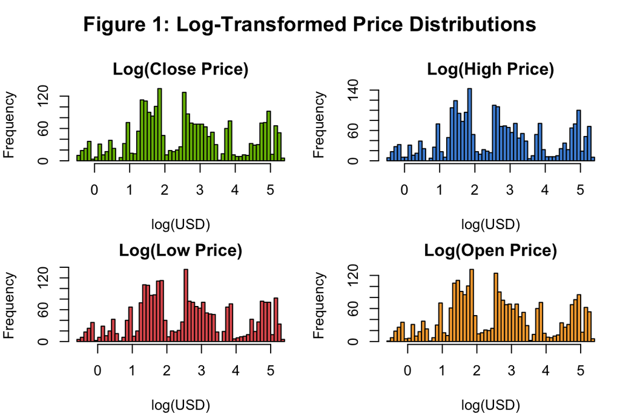

## Bivariate Exploration

### Price and Volume Over Time

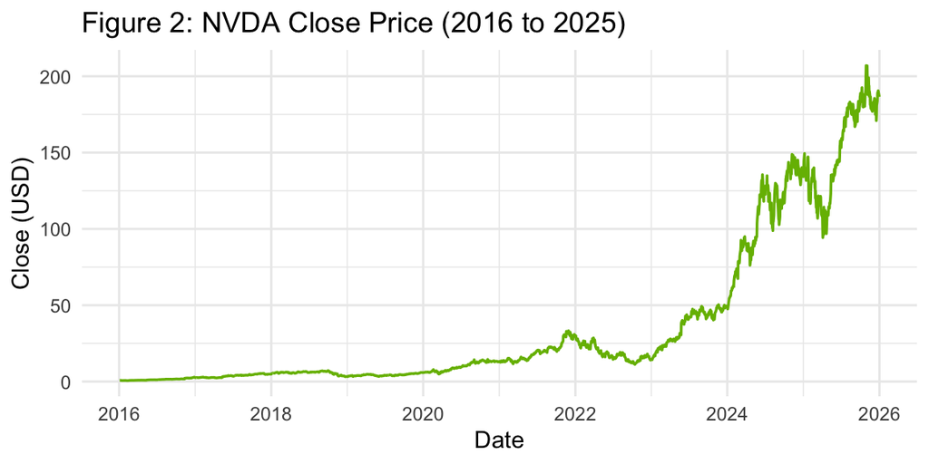

The time series reveals a clear two-regime structure. From 2016 to early 2023, growth was gradual relative to what followed, punctuated by a sharp rally and subsequent drawdown around 2021–2022 tied to the crypto and gaming demand cycle. Beginning in early 2023, NVIDIA experienced a near-vertical price appreciation driven by an explosion in AI infrastructure spending, with its data center GPU business becoming the primary growth engine.

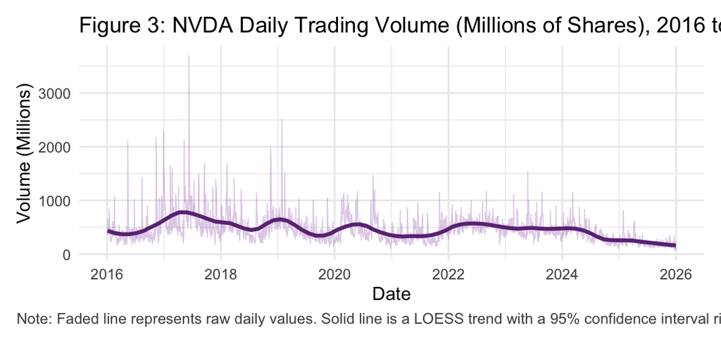

The smoothed trend (Figure 3) reveals that share volume was highest in 2016 to 2018, declined through the early 2020s, and has since stabilized at a lower baseline. This pattern is somewhat counterintuitive given that NVIDIA’s price rose dramatically over the same period. The explanation is mechanical: as the share price increased by orders of magnitude, each individual share became more expensive, so the same dollar amount of institutional activity translates to far fewer shares traded. This motivates our use of `rel_volume` (volume relative to its 20-day moving average) rather than raw share count as a modeling feature, since relative volume is regime-stable and captures unusual institutional activity regardless of the prevailing price level.

### Engineered Features Over Time

Having established the baseline price and volume picture, we now examine how our engineered features evolve across the same time horizon. These plots are critical for understanding whether the features capture distinct market regimes or merely echo the price trend.

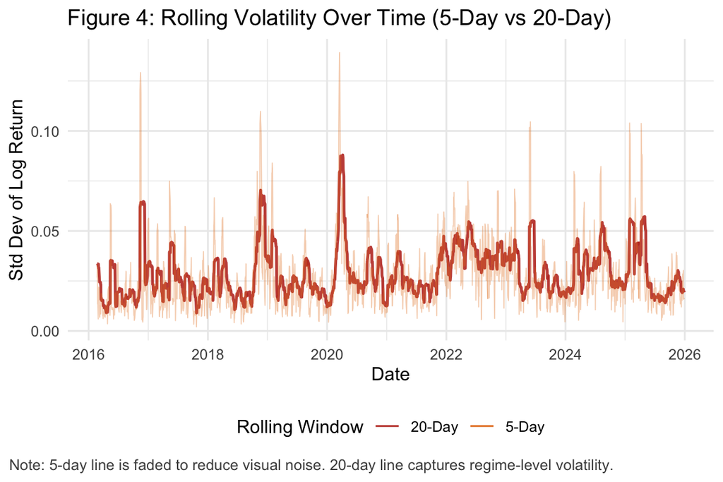

By muting the noise of the 5-day moving average and emphasizing the 20-day trend, the underlying volatility regimes emerge. While the 5-day line highlights acute short-term fluctuations, the 20-day line offers a smoother view of the stock’s price action. Even with this longer-term smoothing, both metrics reflect the high level of risk inherent in an individual equity.

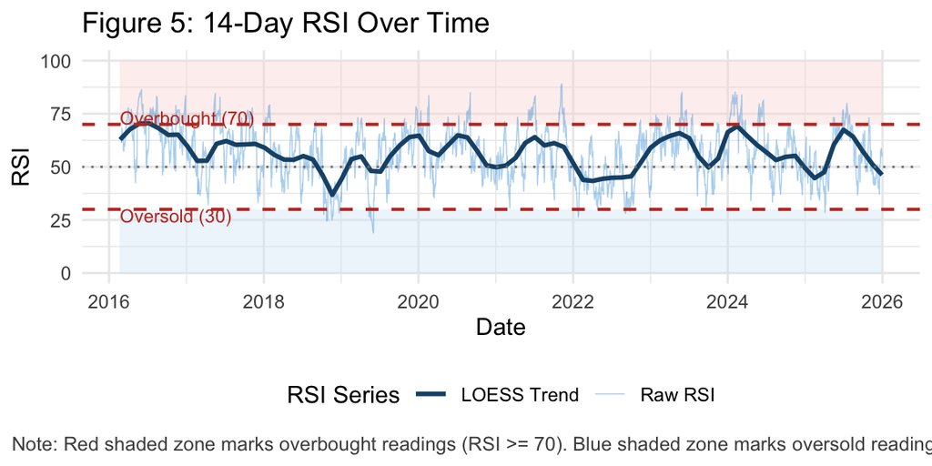

The shaded zones render overbought and oversold conditions immediately legible, removing the need to trace individual spikes. By focusing on the smoothed trend, the medium-term RSI drift becomes apparent. Figure 5 illustrates that overbought conditions occurred more frequently than oversold ones over this period, suggesting a sustained bullish bias in the underlying momentum.

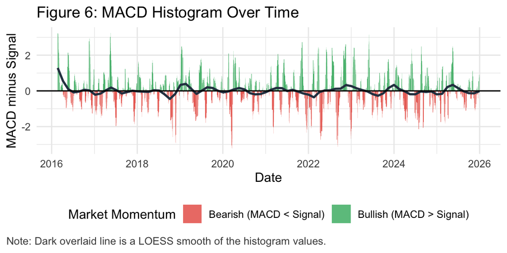

The MACD Histogram data from 2016 to 2025 reveals a market characterized by frequent momentum shifts rather than prolonged, one-sided dominance. By applying a LOESS smooth to the histogram, the underlying momentum cycles become visible, filtering out the daily noise to show periods where bullish or bearish pressure truly gained structural hold. While individual years like 2019 showed a strong bullish lean at 62.3%, the ten-year average remains remarkably balanced, with most years hovering near a 50% split between bullish and bearish days. This suggests that while short-term spikes are aggressive, the long-term momentum regime is mean-reverting, requiring traders to remain agile as the asset oscillates between these overextended states.

## Stationarity Testing

To ensure the validity of our predictive models, we must address the issue of stationarity in our financial data. Stock prices are naturally non-stationary, meaning they exhibit trends and changing mean values over time that makes direct modeling unreliable. If we use raw, non-stationary data, our models may generate false correlations, where they mistake a simple upward price drift for a genuine predictive signal. To confirm this, we use the Augmented Dickey-Fuller (ADF) test, which assesses whether a series has a unit root (is non-stationary).

Converting our data into a stationary format is a fundamental requirement in time-series analysis, as it ensures the model is learning from actual market fluctuations rather than chasing a trend line.

```
## === ADF Test: Raw Close Price ===
```

```
##
##  Augmented Dickey-Fuller Test
##
## data:  df$Close
## Dickey-Fuller = -0.10449, Lag order = 13, p-value = 0.99
## alternative hypothesis: stationary
```

```
##
## === ADF Test: Log Returns ===
```

```
##
##  Augmented Dickey-Fuller Test
##
## data:  log_ret_clean
## Dickey-Fuller = -13.578, Lag order = 13, p-value = 0.01
## alternative hypothesis: stationary
```

For the raw `Close` price, the test returned a p-value of 0.99. Since this is well above the 0.05 threshold, we cannot reject the null hypothesis, confirming the price data is non-stationary and unsuitable for direct modeling. In contrast, when we apply the ADF test to our `log_return` series, the p-value drops to 0.01. This allows us to reject the null hypothesis with high confidence, statistically confirming that the log returns are stationary. By transforming the raw prices into log returns, we have effectively removed the stochastic trend and created a stable series. In other words, by using log returns instead of the given price data, we will be able to ensure our models use and learn legitimate patterns in volatility rather than chasing artificial trends.

## Autocorrelation Plots

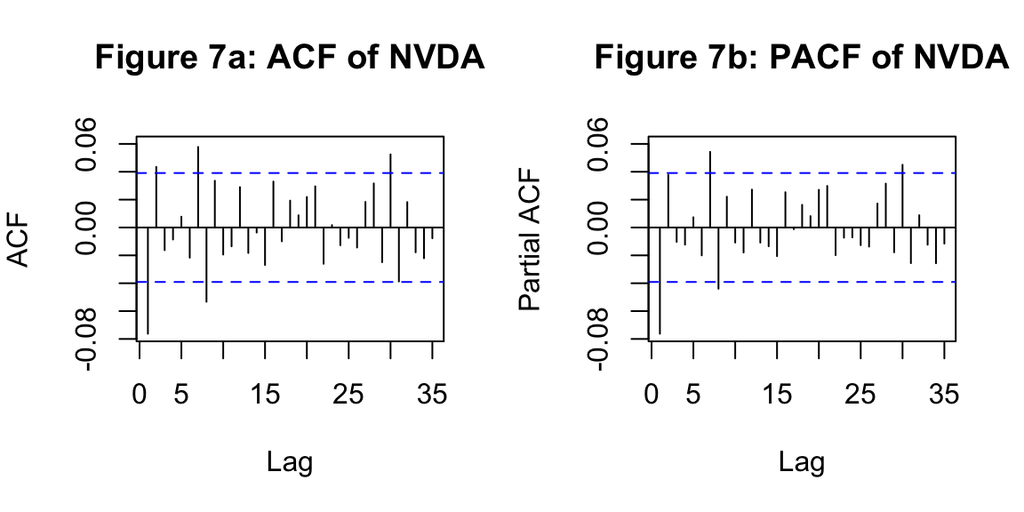

To evaluate the predictability of NVIDIA’s stock, we performed an Autocorrelation Function (ACF) analysis on our stationary log returns. The purpose of an ACF plot is to identify whether the current price movement has any linear dependency on its past values. If a time series exhibits significant autocorrelation, it suggests that historical returns can serve as a predictor for future values; if not, the series behaves as a random walk (implying past data provides no information about future direction).

Our output for the NVDA log returns shows that nearly all spikes fall within the blue dashed lines, which represent the 95% confidence interval for statistical significance. This absence of consistent linear autocorrelation indicates that the daily returns behave essentially as “white noise.”

The PACF plot mirrors these findings, with the vast majority of bars falling within the 95% confidence interval and no consistent repeating pattern across lags.

Although strong linear dependencies are largely absent, this does not rule out ARIMA as a modeling approach. ARIMA can still produce useful short-term forecasts on near-random series, particularly when used to characterize the return distribution and generate a probabilistic forecast interval. We include it in the modeling section as our time-series baseline, alongside the classification models.

## Clustering

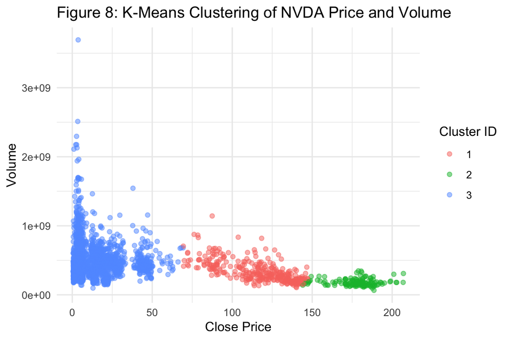

To explore structural segments within the dataset, we performed K-means clustering on the price and volume features. It is important to note that clustering is fundamentally ill-suited for this dataset, as we have already established through our stationarity tests that the data is non-stationary and lacks stable, repeatable patterns. However, as this analysis was a project requirement, we proceeded with a basic K-means approach to empirically demonstrate this limitation.

With the EDA complete, we have established the key properties of the data: a two-regime price history, near-zero autocorrelation in log returns, volatility clustering, and a rich feature set capturing momentum, mean-reversion, and volume dynamics. The following section describes how these features are used within each predictive model.

# Methods

## Feature Summary

All classification models operate on the same 20-feature input vector constructed during the feature engineering step. The table below summarizes each feature, its category, and its modeling rationale.

[output not shown]

This feature set was deliberately designed to be broad. The breadth ensures that if any of these dimensions carry predictive information, the models have the opportunity to find it.

## Problem Formulation

This project uses two complementary approaches to analyze NVIDIA’s stock. First, we apply ARIMA to the log return series to generate short-term forecasts and evaluate how well a classical time-series model captures the return dynamics. Second, we frame next-day price direction as a binary classification problem: given today’s features, will the stock close higher or lower tomorrow? The target variable is defined as:

$$y_t = \mathbf{1}[\text{Close}_{t+1} >
\text{Close}_t]$$

where $y_t = 1$ means the price closes higher the next day and $y_t = 0$ otherwise. For the classification models, each observation consists of the feature vector $\mathbf{x}_t$ from the engineered feature set and the binary label $y_t$.

## Train-Test Split

Because this is a time-series dataset, random shuffling would introduce look-ahead bias. We use a strict chronological split: the first 80% of observations go to training and the final 20% to testing. No information from the test set is used in preprocessing or model fitting.

```
## Training observations: 1984
```

```
## Test observations:     496
```

```
## Features:              20
```

```
## Class balance (train):
```

```
## y_train
##    0    1
##  901 1083
```

## Evaluation Metrics

For the classification models, we evaluate performance on the held-out test set using four standard metrics. Accuracy alone is misleading in financial contexts, a model that always predicts “up” can appear deceptively accurate in a bull market, so we also report Precision, Recall, and F1.

- **Accuracy**: share of days correctly classified
- **Precision**: of predicted-up days, how many were actually up
- **Recall**: of actual up days, how many did the model identify
- **F1 Score**: harmonic mean of precision and recall

## Model 1: ARIMA

### Model Description

Before applying machine learning classifiers, we first ask whether there is any linear temporal structure in the return series that a classical time-series model can exploit. ARIMA is the natural starting point for this question. It is the standard econometric tool for modeling univariate financial time series and is well-established in the literature as a baseline for return forecasting (Box and Jenkins, 1970). If ARIMA cannot find exploitable structure, that is strong evidence that the series is close to a random walk, which directly informs our interpretation of the classification results that follow.

We use `auto.arima` to let the data determine the appropriate model order rather than imposing a specification. Because we already confirmed the log return series is stationary, no differencing is needed and the model fits directly on returns. We treat it as a directional classifier by converting a positive one-step-ahead forecast to an “up” prediction and a negative forecast to “down,” which allows us to evaluate it on the same metrics as the other models. The rolling forecast procedure refits the model on an expanding window for each test observation, avoiding any look-ahead bias.

$$\phi(B)(1 - B)^d r_t = \theta(B)
\varepsilon_t$$

```
## === ARIMA Model Selected ===
```

```
## Series: train_returns
## ARIMA(1,0,0) with non-zero mean
##
## Coefficients:
##           ar1    mean
##       -0.0750  0.0021
## s.e.   0.0224  0.0006
##
## sigma^2 = 0.0009574:  log likelihood = 4081.49
## AIC=-8156.98   AICc=-8156.97   BIC=-8140.2
##
## Training set error measures:
##                        ME       RMSE        MAE MPE MAPE      MASE        ACF1
## Training set 7.010017e-07 0.03092648 0.02163767 NaN  Inf 0.6729154 0.001598083
```

The residual diagnostics below check whether ARIMA has captured all available linear structure. If the ACF spikes are within the confidence bands and the Ljung-Box p-value is above 0.05, the residuals are consistent with white noise and the model is well-specified.

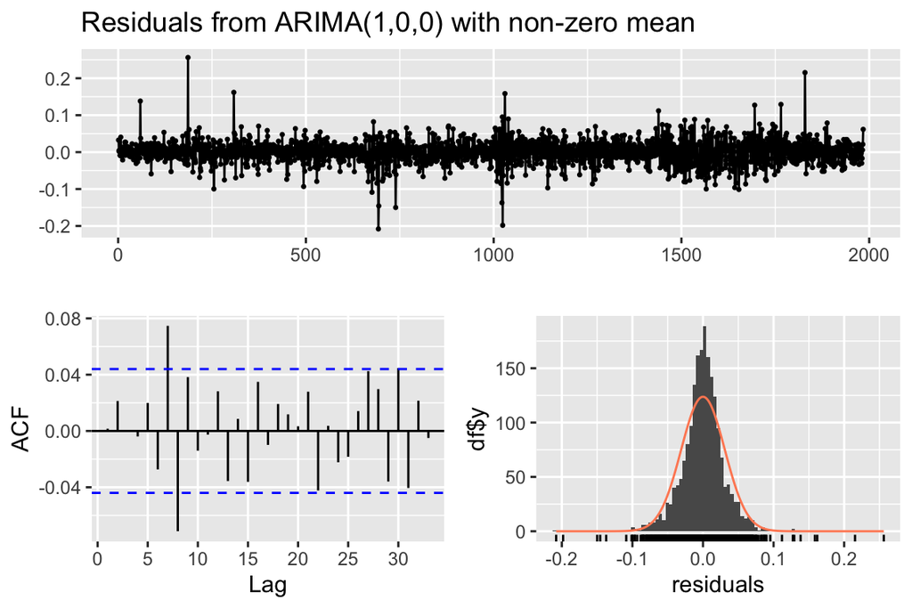

```
##
##  Ljung-Box test
##
## data:  Residuals from ARIMA(1,0,0) with non-zero mean
## Q* = 27.77, df = 9, p-value = 0.001042
##
## Model df: 1.   Total lags used: 10
```

## Baseline: Logistic Regression

### Model Description

Logistic regression is included as the linear baseline for the classification task. The rationale is straightforward: before introducing more complex models, we need to establish whether any signal at all exists in a simple linear combination of the features. If logistic regression cannot outperform random chance, that is a meaningful finding on its own. Any subsequent model that does better can attribute its improvement specifically to non-linear modeling capacity rather than to the features themselves.

We use L2 (ridge) regularization via `cv.glmnet` with the penalty strength selected by 5-fold cross-validation. This is important in our setting because we have 20 features and some of them are correlated (for example, `vol_5d` and `vol_20d` both measure volatility). Without regularization, the model would be prone to assigning large coefficients to correlated features in ways that overfit the training period. Ridge penalization shrinks these coefficients toward zero and produces a more stable, generalizable model.

$$P(y_t = 1 \mid \mathbf{x}_t) =
\frac{1}{1 + e^{-(\beta_0 + \boldsymbol{\beta}^\top
\mathbf{x}_t)}}$$

## Model 2: Random Forest

### Model Description

Logistic regression can only detect linear relationships between features and the target. The reason we add Random Forest is that financial market dynamics are unlikely to be linear. A single technical indicator crossing a threshold may mean very little in isolation, but the same signal in combination with elevated volatility and a recent streak of negative returns may carry real predictive content. Random Forest is well-suited to detect exactly these kinds of joint conditions because it builds an ensemble of decision trees, each of which partitions the feature space along interaction boundaries that a linear model cannot represent.

We also chose Random Forest specifically because it provides feature importance scores, which lets us answer a secondary question beyond prediction accuracy: even if the model cannot predict direction reliably, which features carry the most information? This is analytically useful regardless of overall model performance. We use 500 trees with $\lfloor\sqrt{p}\rfloor$ features considered at each split, which is the standard configuration for classification tasks and provides a good balance between tree diversity and individual tree accuracy.

Table 10: Random Forest Top 10 Features by Mean Decrease in Accuracy

| Feature | MeanDecAcc |
| --- | --- |
| ma_20d | 4.3647 |
| rsi_14 | 2.5255 |
| macd_hist | 2.3428 |
| vol_20d | 2.3197 |
| bb_width | 1.6469 |
| overnight_gap | 1.3481 |
| lag2 | 1.1711 |
| price_vs_sma20 | 1.1599 |
| bb_pct_b | 1.0938 |
| rel_volume | 0.4250 |

## Model 3: Soft Voting Ensemble

### Model Description

Having fit Logistic Regression and Random Forest separately, the natural next step is to ask whether combining them produces better predictions than either alone. The reasoning is that the two models are likely making different kinds of errors. Logistic Regression may be overconfident on days where the linear signal is strong but the true relationship is non-linear. Random Forest may be uncertain on days where a clean linear boundary exists. If their errors are at least partially independent, averaging their probability estimates should cancel some of that noise and yield more reliable predictions than either model individually.

We use soft voting rather than hard voting because it preserves information about each model’s confidence. Hard voting would simply ask each model to cast a 0 or 1 vote, discarding the probability estimate entirely. Soft voting averages the predicted probabilities directly, so a day where both models assign 70% probability to “up” produces a different outcome than a day where one says 95% and the other says 45%, even though both would give the same hard vote. This makes the ensemble more conservative on ambiguous observations, which is desirable in a setting where overconfidence is a known failure mode (as seen in Logistic Regression’s near-perfect Recall).

$$\hat{p}_t^{\text{ensemble}} =
\frac{1}{2}\left(\hat{p}_t^{\text{LR}} +
\hat{p}_t^{\text{RF}}\right)$$

# Results

## Results Summary

Table 11: All Model Performance on Held-Out Test Set

| Model | Accuracy | Precision | Recall | F1 |
| --- | --- | --- | --- | --- |
| ARIMA | 0.5101 | 0.5321 | 0.8296 | 0.6483 |
| Logistic Regression | 0.5444 | 0.5456 | 0.9741 | 0.6995 |
| Random Forest | 0.5222 | 0.5690 | 0.5037 | 0.5344 |
| Soft Voting Ensemble | 0.5484 | 0.5728 | 0.6704 | 0.6177 |

The results above show that all four models perform within a narrow band just above the 50% random-chance baseline, with accuracy ranging from 51.01% (ARIMA) to 54.84% (Soft Voting Ensemble).

The most reliable metric for this task is F1, which balances precision and recall and penalizes the tendency to simply predict “up” every day.

On that metric, Logistic Regression scores highest at 0.6995, but this is driven almost entirely by its near-perfect Recall of 0.9741 rather than any genuine discriminative ability.

Random Forest produces the most balanced profile across all four metrics, with an F1 of 0.5344 and a Precision of 0.5690, suggesting it is the only model that attempts to distinguish up days from down days in a meaningful way.

The Soft Voting Ensemble improves on Random Forest in Accuracy (0.5484 vs. 0.5222) and Precision (0.5728 vs. 0.5690) while pulling Recall back from the extreme seen in Logistic Regression, landing at an F1 of 0.6177. No model clears a threshold that would make it practically actionable as a trading signal.

## ARIMA

As a directional classifier, ARIMA produced an accuracy of 51.01%, precision of 53.21%, recall of 82.96%, and an F1 of 0.6483. The model overwhelmingly predicted “up” throughout the test period, which inflated recall while keeping accuracy barely above a coin flip. This performance reflects the model’s tendency to exploit the underlying upward bias in the dataset; by consistently favoring the ‘up’ class, the model achieved high recall simply because the asset spent more time in an upward-trending state than a downward-trending one.

## Logistic Regression

Logistic Regression achieved an accuracy of 54.44%, precision of 54.56%, recall of 97.41%, and an F1 of 0.6995. The high recall of 0.9741 reveals that the model essentially predicts “up” on nearly every test day. Unlike ARIMA, which suffers from trying to map continuous forecast errors to binary outcomes, the Logistic Regression struggle is rooted in model simplicity: after L2 regularization, the coefficients for all 20 features were suppressed close to zero. This indicates that no linear combination of the technical indicators could provide enough signal to overcome the regularization penalty. Consequently, the model defaults to the majority class as the mathematically optimal. Like the ARIMA model, the resulting accuracy of 54.44% merely tracks the base rate of upward-trending days in the test set, rather than demonstrating any genuine predictive skill

## Soft Voting Ensemble

The soft voting ensemble achieved an accuracy of 54.84%, precision of 57.28%, recall of 67.04%, and an F1 of 0.6177. On the surface, these numbers look like an improvement over the individual models, but a closer reading suggests the ensemble is not genuinely better.

Its recall of 67.04% is substantially higher than Random Forest’s 50.37%, which means the averaged probabilities pulled predictions back toward the “always up” behavior seen in Logistic Regression. The precision gain over Random Forest is negligible: 57.28% versus 56.90%, a difference of less than half a percentage point.

What the ensemble actually produced is a weighted average of two biases rather than a correction of them. Logistic Regression’s strong upward skew dominated the averaging process, and Random Forest’s more balanced output was not enough to counteract it. The modest accuracy gain to 54.84% and the elevated recall both point to the same conclusion: the ensemble is trending upward for the same structural reason as ARIMA and Logistic Regression, namely that NVDA closes higher on more days than it closes lower over this sample period, and not because the model has found a real directional signal.

## Comparative Summary

All four models fall within an accuracy range of 51.01% to 54.84%, clustered narrowly above the 50% random-chance baseline. On precision, which is the most actionable metric in a financial setting, the Soft Voting Ensemble leads at 57.28%, followed by Random Forest at 56.90%. These figures are consistent with published results on single-stock direction prediction: Fischer and Krauss (2018) report directional accuracies of 55% to 60% for Random Forest and LSTM models on S&P 500 constituents, achieved using cross-sectional features and substantially larger datasets. State-of-the-art models using transformer architectures, options flow data, and real-time sentiment rarely exceed 58% directional accuracy on individual large-cap equities.

For context, a buy-and-hold position in NVDA over the 2016 to 2025 sample period would have returned over 3,000%, driven by structural factors such as AI infrastructure demand and GPU market dominance.

# Discussion

## Findings

The central finding of this project is that NVIDIA’s daily return series behaves very close to a random walk, and that this property is robust across model classes. ARIMA, Logistic Regression, Random Forest, and a Soft Voting Ensemble all produced accuracy figures between 51% and 55%, with no model demonstrating the kind of consistent directional edge that would be required for a profitable trading strategy. The fact that all four approaches converge on the same result is actually a stronger conclusion than if one had succeeded; it rules out model-specific explanations and points directly at the data-generating process itself as the limiting factor. This is precisely what the Efficient Market Hypothesis predicts for a heavily covered, highly liquid large-cap stock.

The results also taught us that Recall is a misleading metric in this setting. Logistic Regression’s Recall of 0.9741 looks strong in isolation, but it was achieved by predicting “up” on nearly every single test day, not by identifying genuine up days. Random Forest’s far lower Recall of 0.5037, paired with its higher Precision of 0.5690, is the more honest result: it made fewer “up” calls and was right more often when it did. The Soft Voting Ensemble reinforced this lesson by pulling Recall down from 0.9741 to 0.6704 while pushing Precision up to 0.5728, the highest of any model. In a financial context, precision is the metric that matters most; a high-recall strategy that fires every day provides no actionable signal.

## Limitations

Our models ultimately struggled because price history alone is a thin signal for predicting future movements. By relying exclusively on NVIDIA’s internal OHLCV data, we lacked the external context that actually moves markets, such as how the broader tech sector or macroeconomic shifts—like interest rate changes—influence NVIDIA’s performance. Furthermore, the entire decade was treated as one consistent block of data. However, this ignores the considerations of the economic landscape, namely the fact that the pre-2023 slow-growth market and the recent AI-driven explosion were very different economic environments.

## Final Takeaway

The results of this project align closely with the Efficient Market Hypothesis (EMH) as formalized by Eugene Fama. The EMH posits that in a highly liquid market, all publicly observable and computationally extractable information is already reflected in the current price. For a stock like NVIDIA, one of the most scrutinized assets in the world, this competition is immense. Its price is continuously shaped by institutional investors, analyst coverage, and high-frequency algorithms that possess resources far beyond those of a standard academic analysis. Under these conditions, any signal that can be extracted from publicly available price and volume data is, by definition, a signal that the market has already acted on.

This is also why diversification exists as a foundational principle of portfolio management. Since individual stock movements are close to unpredictable, spreading exposure across many uncorrelated assets is the only reliable way to capture returns without taking on concentrated directional risk.

Even at the frontier of quantitative finance, achieving consistent directional accuracy above 60% on a single equity is exceptionally rare and notoriously difficult to sustain. Ultimately, until statistical models evolve from simple pattern-matching against historical price sequences to a deeper, reasoning-based understanding of the economic landscape, they will remain fundamentally constrained. The gap between what these models can extract from static data and the dynamic, qualitative reality that actually drives market returns remains the final frontier of financial forecasting.

# References

Cont, R. (2001). “Empirical properties of asset returns.” Quantitative Finance.

Box, G. E. P., & Jenkins, G. M. (1970). Time Series Analysis: Forecasting and Control.

Breiman, L. (2001). “Random Forests.” Machine Learning, 45, 5–32.

Dickey, D. A., & Fuller, W. A. (1979). “Distribution of the estimators for autoregressive time series.” JASA.

Fischer, T., & Krauss, C. (2018). “Deep learning with long short-term memory networks for financial market predictions.” European Journal of Operational Research.

Hyndman, R. J., & Khandakar, Y. (2008). “Automatic time series forecasting: the forecast package for R.” Journal of Statistical Software, 27(3).

# Appendix

The code for the project has been attached in the .R file, `Data 210 Final Project Code.R`. It contains more visualizations though is a lot more disorganized than this report. Alternatively, you can look on the GitHub, https://github.com/txchnothunder/Data-210-Final-Project, which has the same .R file as well as the .Rmd and pdf of the project.